# R Notebook

Filtering the data to get the candidate transcripts for analysis

First we import the edgeR library from bioconductor

```r
source("http://bioconductor.org/biocLite.R")
```

```
Bioconductor version 3.4 (BiocInstaller 1.24.0), ?biocLite for help
```

```r
biocLite()
```

[output not shown]

```
Update all/some/none? [a/s/n]:
```

```r
a
```

[output not shown]

```r
biocLite("edgeR")
```

[output not shown]

```
Update all/some/none? [a/s/n]:
```

```r
a
```

[output not shown]

```r
library(edgeR)
```

Then we read the database

```r
setwd("C:/Users/Devin/Documents/GradSchool/IowaState/EEOB_546X/BCB546X-Spring2017_Valerin_final_project")
```

```
The working directory was changed to C:/Users/Devin/Documents/GradSchool/IowaState/EEOB_546X/BCB546X-Spring2017_Valerin_final_project inside a notebook chunk. The working directory will be reset when the chunk is finished running. Use the knitr root.dir option in the setup chunk to change the the wo…
```

```r
getwd()
```

```
[1] "C:/Users/Devin/Documents/GradSchool/IowaState/EEOB_546X/BCB546X-Spring2017_Valerin_final_project"
```

```r
counts_data<-read.delim("Asparagus.RSEM_genecounts.txt", check.names=FALSE, stringsAsFactors = FALSE)
```

We select only the rows that have a CPM bigger than 1 in at least three libraries, which should reduced the number of tested genes to 19 986

```r
cd<-DGEList(counts=counts_data)
keep <- rowSums(cpm(cd)>1) >= 3
cd <- cd[keep, , keep.lib.sizes=FALSE]
```

If we see the number of rown in the list we get a very close measure of the expected number of genes

```r
nrow(cd)
```

```
[1] 19980
```

Then we can create the groups that we are going to use for the experimental design

```r
group_line<-factor(c(88,88,88,89,89,89,103,103,103,9,9))
group_sex <- factor(c("Female", "Male", "Super Male",   "Female",   "Male", "Super Male",   "Female",   "Male", "Super Male",   "Female",   "Male"))
```

Then we build the design as an additive model, and estimate the three types os dispersion

```r
design <- model.matrix(~group_line + group_sex)
rownames(design) <- colnames(cd)
#cd <- estimateDisp(cd, design)
cd <- estimateGLMCommonDisp(cd, design)
cd <- estimateGLMTrendedDisp(cd, design)
cd <- estimateGLMTagwiseDisp(cd, design)
fit <- glmFit(cd, design)
```

Let`s explore a little more the design object. It indicates the experimental design we are using to analyze the data

```r
design
```

```
        (Intercept) group_line88 group_line89 group_line103 group_sexMale
88F               1            1            0             0             0
88M               1            1            0             0             1
88supM            1            1            0             0             0
89F               1            0            1             0             0
89M               1            0            1             0             1
89supM            1            0            1             0             0
103F              1            0            0             1             0
103M              1            0            0             1             1
103supM           1            0            0             1             0
9F                1            0            0             0             0
9M                1            0            0             0             1
        group_sexSuper Male
88F                       0
88M                       0
88supM                    1
89F                       0
89M                       0
89supM                    1
103F                      0
103M                      0
103supM                   1
9F                        0
9M                        0
attr(,"assign")
[1] 0 1 1 1 2 2
attr(,"contrasts")
attr(,"contrasts")$group_line
[1] "contr.treatment"

attr(,"contrasts")$group_sex
[1] "contr.treatment"
```

Therefore, the model takes the intercept as the baseline (Female phenotype), and then each coeficient in the desing corresponds to: (2) line88, (3) line89, (4) line103, (5) Male, (6) Super Male.

Now the comparisons fem vs sup male and an example of a plot (taking the coef=6 vs 1-female, default)

```r
lrt_FSupM <- glmLRT(fit, coef=6)
summary(de_FemvsSupMal <- decideTestsDGE(lrt_FSupM, adjust.method="fdr"))
```

```
   [,1]
-1    37
0  19518
1    425
```

```r
FDR_FSupM <- p.adjust(lrt_FSupM$table$PValue, method="fdr")
sum(FDR_FSupM < 0.05)
```

```
[1] 462
```

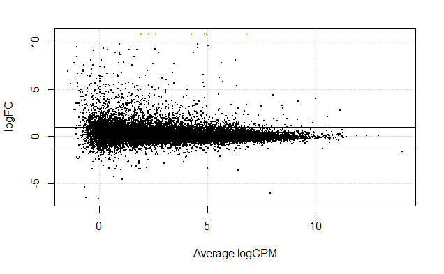

```r
detags <- rownames(cd)[as.logical(de_FemvsSupMal)]
plotSmear(lrt_FSupM, de_FemvsSupMal.tags=detags)
abline(h=c(-1, 1))
```

```r
lrt_FM <- glmLRT(fit, coef=5)
summary(de_FemvsMal <- decideTestsDGE(lrt_FM, adjust.method="fdr"))
```

```
   [,1]
-1     1
0  19717
1    262
```

```r
FDR_FM <- p.adjust(lrt_FM$table$PValue, method="fdr")
sum(FDR_FM < 0.05)
```

```
[1] 263
```

male vs sup male

```r
lrt_MSupM <- glmLRT(fit, contrast=c(0,0,0,0,-1,1))
summary(de_MalvsSupMal <- decideTestsDGE(lrt_MSupM, adjust.method="fdr"))
```

```
   [,1]
-1    13
0  19951
1     16
```

```r
FDR_MSupM <- p.adjust(lrt_MSupM$table$PValue, method="fdr")
sum(FDR_MSupM < 0.05)
```

```
[1] 29
```

If we sum up all the comparisons results we get 754 DEG, including duplicates